# Homework 5

*Kenneth Luna*

For this assignment, we will again be using the `forecast` library.

```r
library("forecast")
```

The dataset is the unemployment rate, monthly, seasonally adjusted.

```r
data <- read.csv("http://ptrckprry.com/course/forecasting/data/unemployment.csv")
date <- as.Date(data$date)
time <- 1:length(date)
unemp <- data$unemployment
```

## Part A

We first construct the log unemployment series, and its first two differences:

```r
log.unemp <- log(unemp)
diff.log.unemp <- c(NA, diff(log.unemp))
diff2.log.unemp <- c(NA, diff(diff.log.unemp))
```

Now, we use time series plots, ACFs and PACFs to determine the appropriate level of differencing.

Here are the plots for the original series:

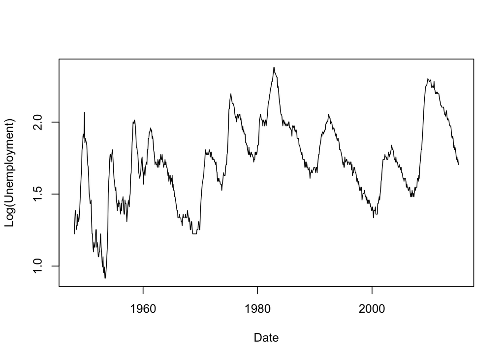

```r
par(mfrow=c(1,1))
plot(as.Date(date), log.unemp, type="l",
     xlab="Date", ylab="Log(Unemployment)")
```

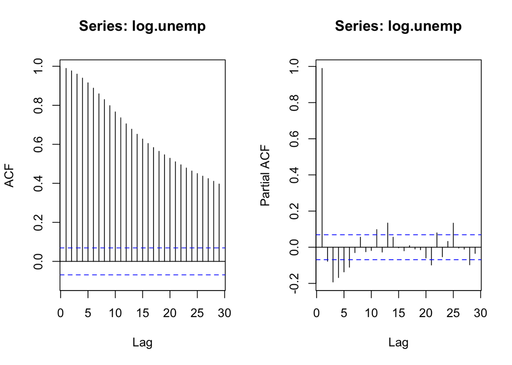

```r
par(mfrow=c(1,2))
Acf(log.unemp)
Pacf(log.unemp)
```

Here are the plots for the first difference:

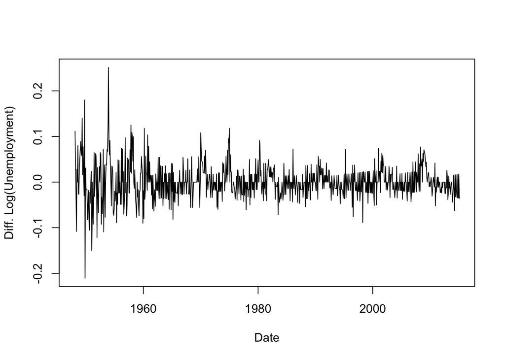

```r
par(mfrow=c(1,1))
plot(as.Date(date), diff.log.unemp, type="l",
     xlab="Date", ylab="Diff. Log(Unemployment)")
```

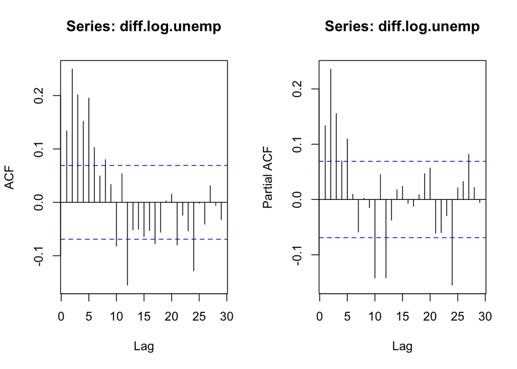

```r
par(mfrow=c(1,2))
Acf(diff.log.unemp)
Pacf(diff.log.unemp)
```

Here are the plots for the second difference:

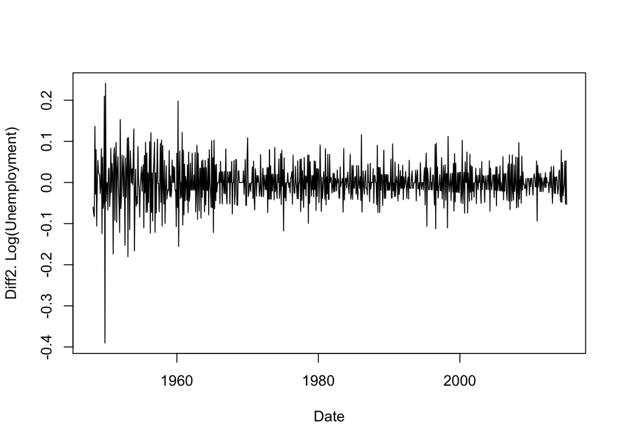

```r
par(mfrow=c(1,1))
plot(as.Date(date), diff2.log.unemp, type="l",
     xlab="Date", ylab="Diff2. Log(Unemployment)")
```

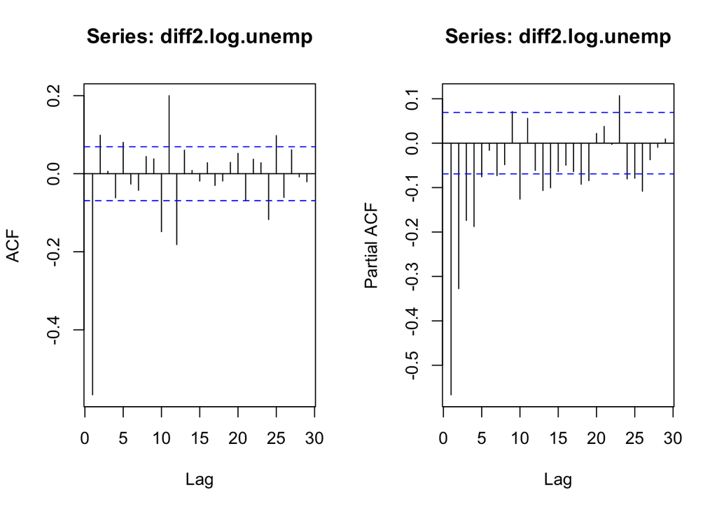

```r
par(mfrow=c(1,2))
Acf(diff2.log.unemp)
Pacf(diff2.log.unemp)
```

**Choose d for an ARIMA model. Explain your reasoning.**

For this ARIMA model, (d) should be 1. The reason (d) should be 1 is because when we observe (d) = 2, lag-1 is extremely negative, indicating that we potentially over-differenced.

## Part B

```r
fit.00 <- Arima(diff.log.unemp, c(0, 0, 0), include.constant=FALSE)
fit.01 <- Arima(diff.log.unemp, c(0, 0, 1), include.constant=FALSE)
fit.02 <- Arima(diff.log.unemp, c(0, 0, 2), include.constant=FALSE)
fit.10 <- Arima(diff.log.unemp, c(1, 0, 0), include.constant=FALSE)
fit.11 <- Arima(diff.log.unemp, c(1, 0, 1), include.constant=FALSE)
fit.12 <- Arima(diff.log.unemp, c(1, 0, 2), include.constant=FALSE)
fit.20 <- Arima(diff.log.unemp, c(2, 0, 0), include.constant=FALSE)
fit.21 <- Arima(diff.log.unemp, c(2, 0, 1), include.constant=FALSE)
fit.22 <- Arima(diff.log.unemp, c(2, 0, 2), include.constant=FALSE)

fit.00c <- Arima(diff.log.unemp, c(0, 0, 0), include.constant=TRUE)
fit.01c <- Arima(diff.log.unemp, c(0, 0, 1), include.constant=TRUE)
fit.02c <- Arima(diff.log.unemp, c(0, 0, 2), include.constant=TRUE)
fit.10c <- Arima(diff.log.unemp, c(1, 0, 0), include.constant=TRUE)
fit.11c <- Arima(diff.log.unemp, c(1, 0, 1), include.constant=TRUE)
fit.12c <- Arima(diff.log.unemp, c(1, 0, 2), include.constant=TRUE)
fit.20c <- Arima(diff.log.unemp, c(2, 0, 0), include.constant=TRUE)
fit.21c <- Arima(diff.log.unemp, c(2, 0, 1), include.constant=TRUE)
fit.22c <- Arima(diff.log.unemp, c(2, 0, 2), include.constant=TRUE)

models <- data.frame(p = rep(c(0, 0, 0, 1, 1, 1, 2, 2, 2), 2),
                     d = rep(1, 18),
                     q = rep(c(0, 1, 2), 6),
                     include.constant = c(rep(FALSE, 9), rep(TRUE, 9)),
                     loglik = c(fit.00$loglik, fit.01$loglik, fit.02$loglik,
                                fit.10$loglik, fit.11$loglik, fit.12$loglik,
                                fit.20$loglik, fit.21$loglik, fit.22$loglik,
                                fit.00c$loglik, fit.01c$loglik, fit.02c$loglik,
                                fit.10c$loglik, fit.11c$loglik, fit.12c$loglik,
                                fit.20c$loglik, fit.21c$loglik, fit.22c$loglik),
                     aicc = c(fit.00$aicc, fit.01$aicc, fit.02$aicc,
                                fit.10$aicc, fit.11$aicc, fit.12$aicc,
                                fit.20$aicc, fit.21$aicc, fit.22$aicc,
                                fit.00c$aicc, fit.01c$aicc, fit.02c$aicc,
                                fit.10c$aicc, fit.11c$aicc, fit.12c$aicc,
                                fit.20c$aicc, fit.21c$aicc, fit.22c$aicc)
                     )
```

**What (p,d,q) is selected by AICC? Does the model include a constant?**

Based on this analysis, the best fitting model is ARIMA(2,1,2) with an AICC value of -3050. It is the most negative in this case. The model does not include a constant.

## Part C

Here is the estimated model:

```r
# edit and uncomment the following two lines

fit <- Arima(log.unemp, c(2,1,2), include.constant = FALSE)
print(fit)
```

```
## Series: log.unemp
## ARIMA(2,1,2)
##
## Coefficients:
##          ar1      ar2      ma1     ma2
##       1.6406  -0.7499  -1.5943  0.7893
## s.e.  0.0564   0.0566   0.0523  0.0543
##
## sigma^2 estimated as 0.001307:  log likelihood=1530.14
## AIC=-3050.27   AICc=-3050.2   BIC=-3026.82
```

**Are all of the parameters statistically significant?**

All the parameters are statistically significant based on their relatively high z-statistic values.

## Part D

**Write the complete form of the fitted model. (No code required.)**

x(t) = 1.64 * x(t-1) + -.7499 * x(t-2) + eps(t) + -1.59 * eps(t-1) + .7893 * eps(t-2)

## Part E

Here are the Ljung-Box statistics for lack of fit:

```r
resid <- residuals(fit)

Box.test(resid, lag=12, type = "Ljung-Box", fitdf=4)
```

```
##
##  Box-Ljung test
##
## data:  resid
## X-squared = 38.1645, df = 8, p-value = 7.019e-06
```

```r
Box.test(resid, lag=24, type = "Ljung-Box", fitdf=4)
```

```
##
##  Box-Ljung test
##
## data:  resid
## X-squared = 74.0458, df = 20, p-value = 3.927e-08
```

```r
Box.test(resid, lag=36, type = "Ljung-Box", fitdf=4)
```

```
##
##  Box-Ljung test
##
## data:  resid
## X-squared = 92.9167, df = 32, p-value = 7.519e-08
```

```r
Box.test(resid, lag=48, type = "Ljung-Box", fitdf=4)
```

```
##
##  Box-Ljung test
##
## data:  resid
## X-squared = 102.0211, df = 44, p-value = 1.66e-06
```

**Does the model seem to be adequate?**

The small p-values indicate dependence, therefore I would conclude that this model is inadequate for this analysis.

## Part F

Here is a plot of the residuals, along with the ACF and the PACF of the residuals:

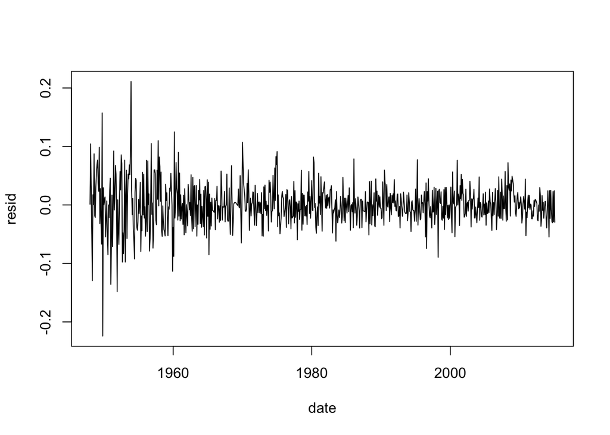

```r
par(mfrow=c(1,1))
plot(date, resid, type="l")
```

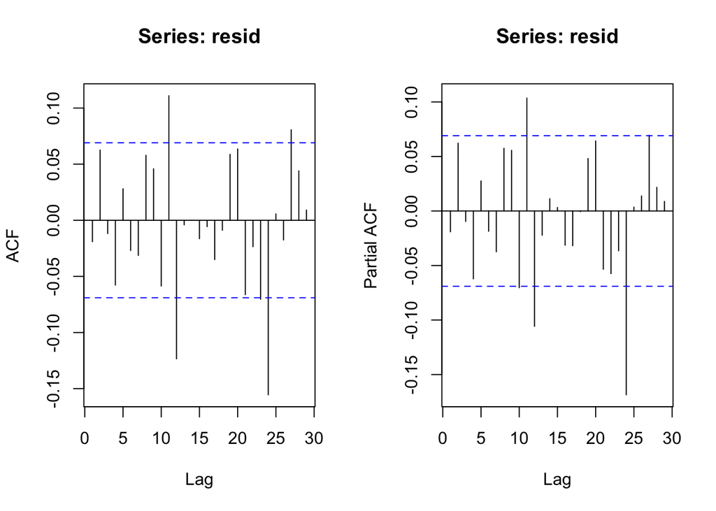

```r
par(mfrow=c(1,2))
Acf(resid)
Pacf(resid)
```

**Do these plots indicate any inadequacies in the model?**

The plot for residuals on the fitted model seems to have a zero mean from just looking at it. Based on these ACF and PACF plots, there does seem to be some inadequecies as some spikes extend outside of the significance limits, indicating they are more than just white noise.

## Part G

Here is the original data, along with the forecasts and 95% forecast intervals for lead times 1 to 30:

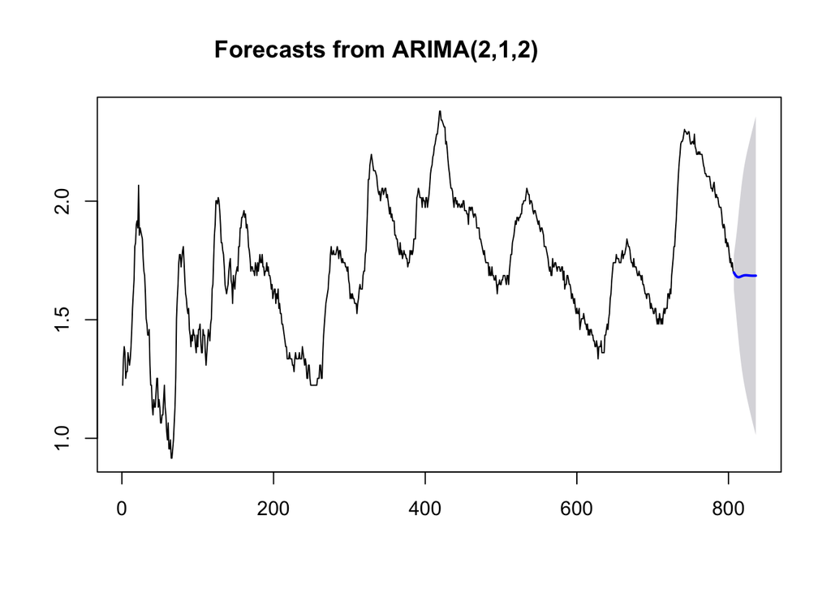

```r
par(mfrow=c(1,1))
plot(forecast(fit, h=30, level = 95))
```

**Do the forecasts seem reasonable?**

**Do the forecast intervals seem excessively wide?**

I do believe the forecast seems a bit wide. The bottom end of the 95% CI goes as low as the lowest record unemployment recording in this data and as high as the highest.